# Introduction to Statistics

Bennett Kleinberg

Week 5

## Week 5

- Part 1: Problems in z-score paradise
- Part 2: the t-statistic
- Part 3: one-sample hypothesis testing

PART 1: Problems in z-score paradise

## Our approach so far

- from a population
- to a distribution of expected sample means
- to a z-score
- to a probability

## Population

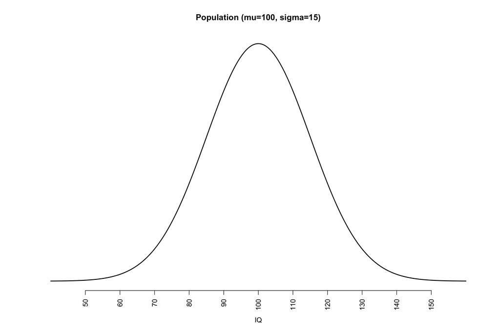

## Central limit theorem

Properties of the distribution of sample means

- Shape: normal
- mean: $\mu=100$
- standard error $SE = \frac{\sigma}{\sqrt{n}}$

For a sample of $n=400$:

$SE=\frac{\sigma}{\sqrt{n}}=\frac{15}{\sqrt{400}}= \frac{15}{20} = 0.75$

## Distr. of sample means

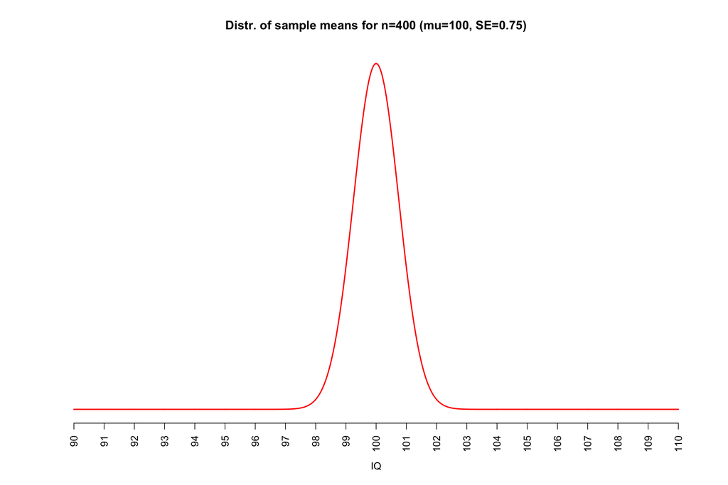

## Increasing n

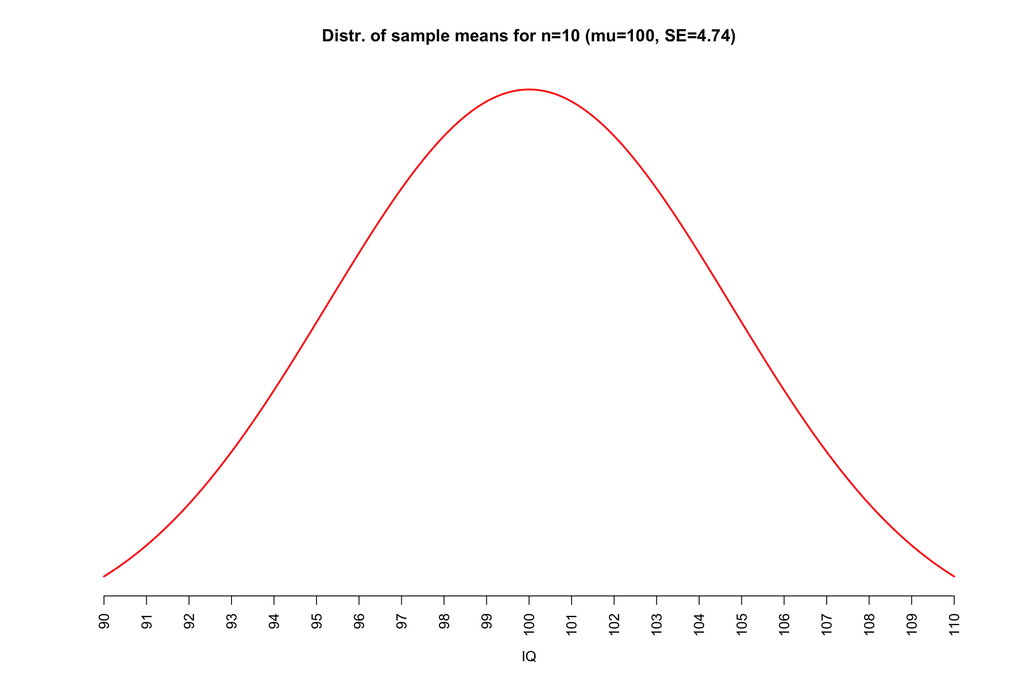

## Increasing n

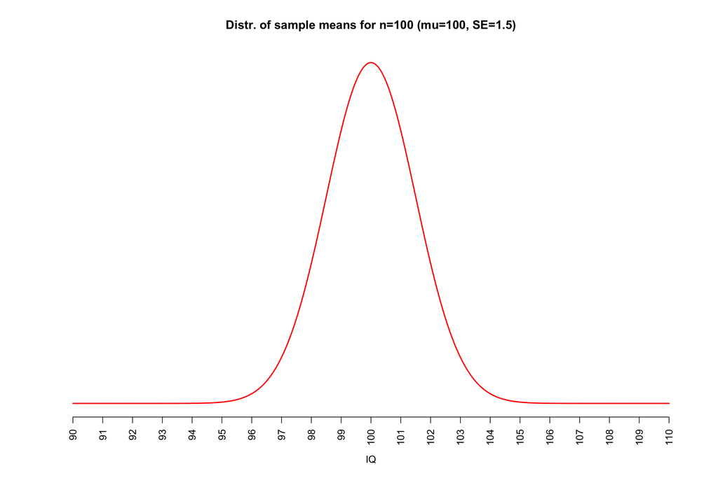

## Increasing n

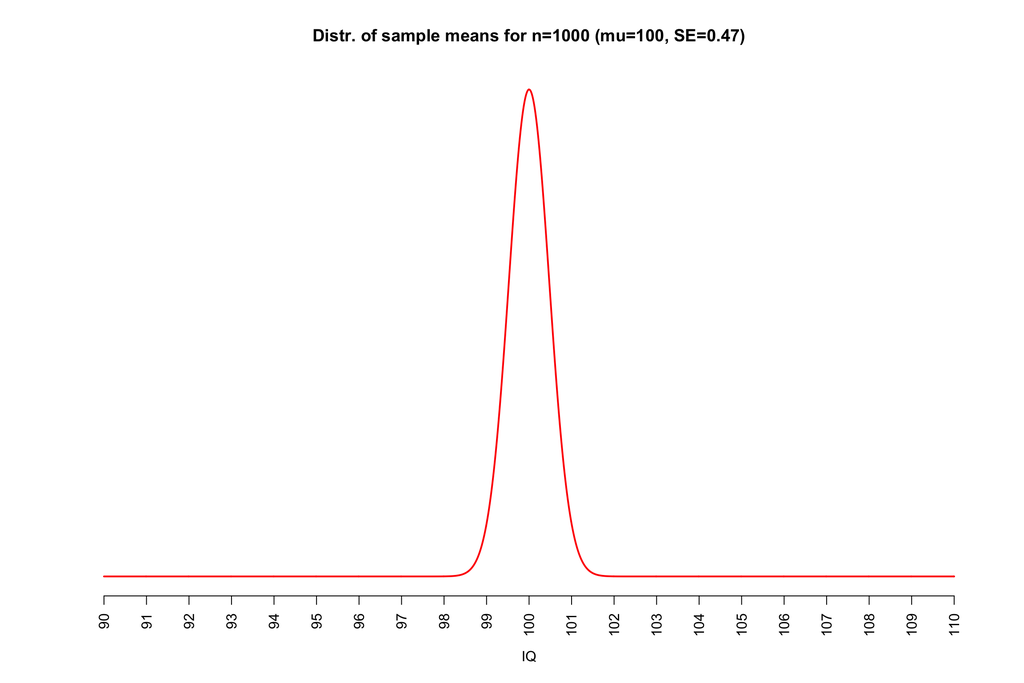

## Increasing n

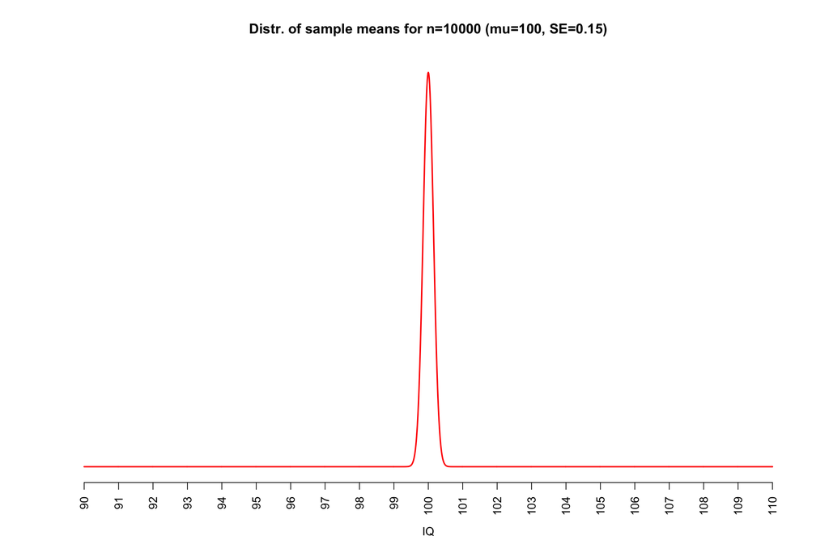

## Probabilities

Data from our sample of $n=400$ –> $\overline{X} = 102$

$z=\frac{M-\mu}{SE}=\frac{\overline{X}-\mu}{\sigma_{M}}$

Here:

$z=\frac{102-100}{0.75} = 2.67$

## Unit table lookup

Find the tail probabilities for $z=2.67$

| z | body | tail | M-to-z |
| --- | --- | --- | --- |
| 2.67 | .9962 | .0038 | .4962 |

p-value: $p=.0038$

## Trouble is looming

- we need the distribution of sampling means
- so we can work with z-scores
- for that, we need the $SE$
- for the $SE$, we need two ingredients:
  - sample size $n$
  - population standard deviation $\sigma$

Close to a circularity problem: we make an inference about a population *based on* a population parameter.

So why the inference?

## Working without $\sigma$

- normally, we don’t have access to the population
- so we don’t know $\sigma$

How can we work without $\sigma$?

*We need a way to address the problem of not having access to the population!*

PART 2: the t-statistic

## The z-score problem

We need a way to address the *missing population* problem!

Solution:

We simply **estimate** the population standard deviation!

## Remember: biased vs unbiased

When we sampled, we calculated a *sample variance* and *sample SD*.

Since dividing by $n$ biases the sample statistic, we corrected for that.

$s^2 = \frac{SS}{n-1}=\frac{SS}{df}$

$s=\sqrt{s^2}$

## We used the estimate

When we don’t have access to $\sigma$, we use its estimate $s$:

New formula for the standard error $SE$:

- original $SE = \sigma_{M}= \frac{\sigma}{\sqrt{n}}$
- estimated $SE = s_{M} = \frac{s}{\sqrt{n}} = \sqrt{\frac{s^2}{n}}$

**The z-score then becomes a t-statistic**

## t-statistic

From z to t:

$t=\frac{M-\mu}{s_{M}}$

This is the z-score but with the estimated standard error (based on the sample variance).

## Degrees of freedom

In: $s^2 = \frac{SS}{n-1}=\frac{SS}{df}$

The $n-1$ is called the degrees of freedom.

e.g. for $n=400$, the sample variance has $400-1=399$ degrees of freedom.

## The t-distribution

Same logic:

For every (theoretically) possible sample, we can obtain the mean and transform it to a z-score. This results in: **the z-score distribution**

For every (theoretically) possible sample, we can obtain the mean and transform it to a t-statistic. This results in: **the t-distribution**

## t-distribution

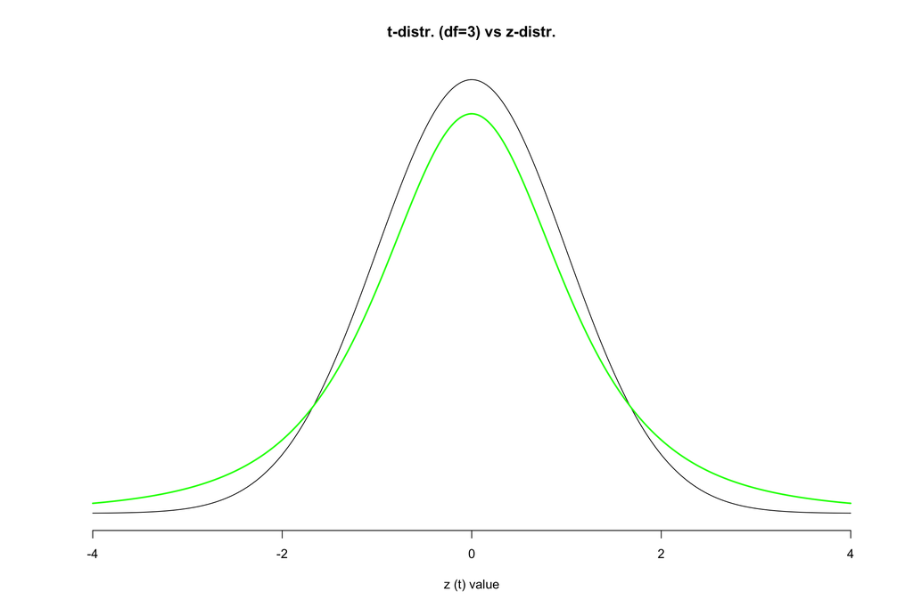

## What’s the difference?

Conceptually:

- the t-distr. is flatter
- the z-distr. has more “peak”

This is because we use the **estimated SE**

## What’s the difference?

Statistically;

$z=\frac{M-\mu}{SE}=\frac{M-\mu}{\frac{\sigma}{\sqrt{n}}}$

$t=\frac{M-\mu}{s_{M}}=\frac{M-\mu}{\frac{s}{\sqrt{n}}}$, where $s=\sqrt{\frac{SS}{n-1}}$

For the t-statistic, we always use the sample variance for the estimated standard error!

**Every sample slightly different!**

## The t-family

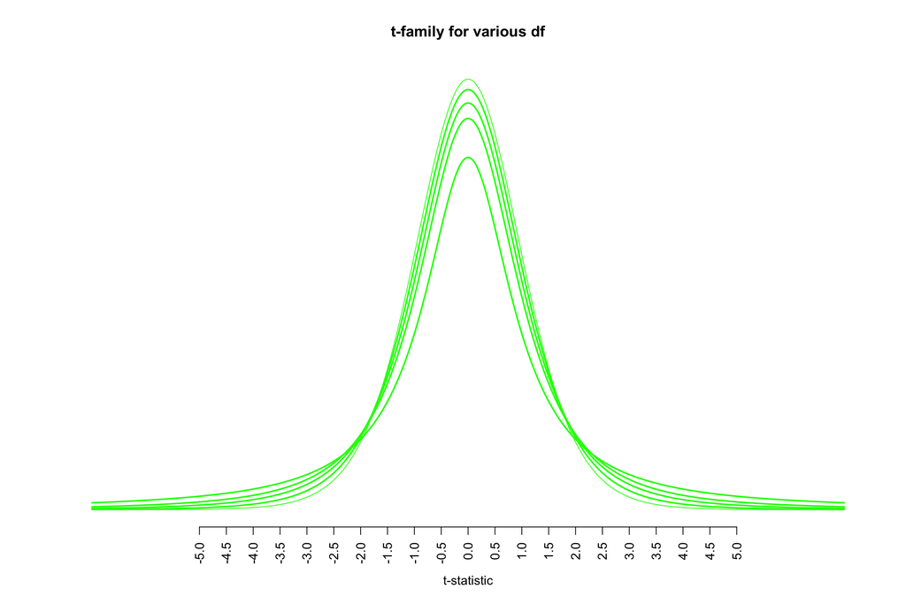

## The t-family

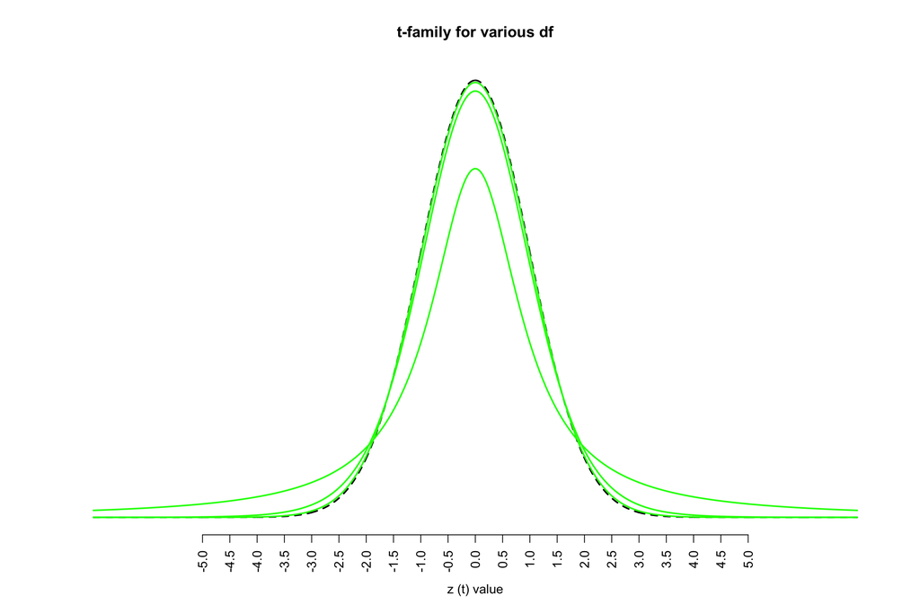

## Probabilities and t

Same logic as with the z-score

We are now interested in the tails only:

Remember: the t-distribution depends on the degrees of freedom (df)

Similar to unit table, we now have a **t-distribution table** (Appendix B.2, p. 651-652)

## Table look-up

- For the z-score:
  - given $z$, locate
  - tail/body proportions
- For the t-statistic:
  - given the degrees of freedom and the tail proportions, locate
  - the critical t-statistic
  - (differs for one-tailed and two-tailed same logic as before)

## t-distr. table

For one-tailed tests:

| df | 0.05 | 0.01 | 0.005 |
| --- | --- | --- | --- |
| 1 | 6.314 | 31.821 | 63.657 |
| 5 | 2.015 | 3.365 | 4.032 |
| 60 | 1.671 | 2.390 | 2.660 |

## Critical region (1-tailed)

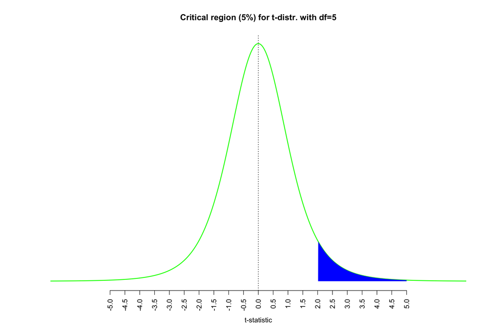

## Critical region (1-tailed)

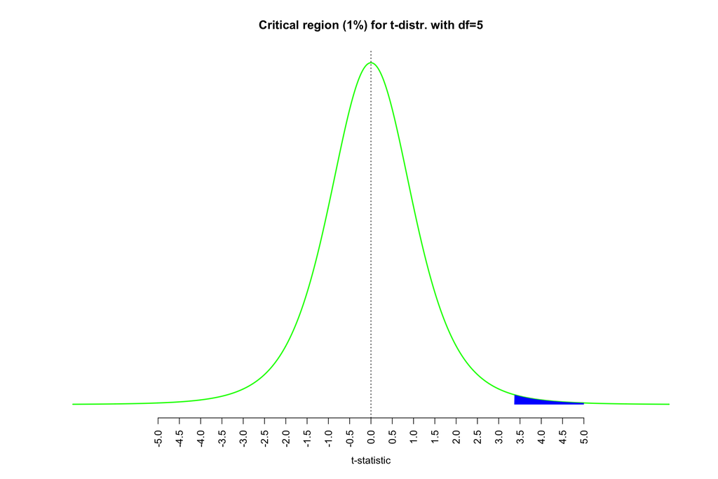

## t-distr. table

For two-tailed tests:

| df | 0.05 | 0.01 |
| --- | --- | --- |
| 1 | 12.706 | 63.657 |
| 5 | 2.571 | 4.032 |
| 60 | 2.000 | 2.660 |

In **both tails**, so positive and negative!

## Critical regions (2-tailed)

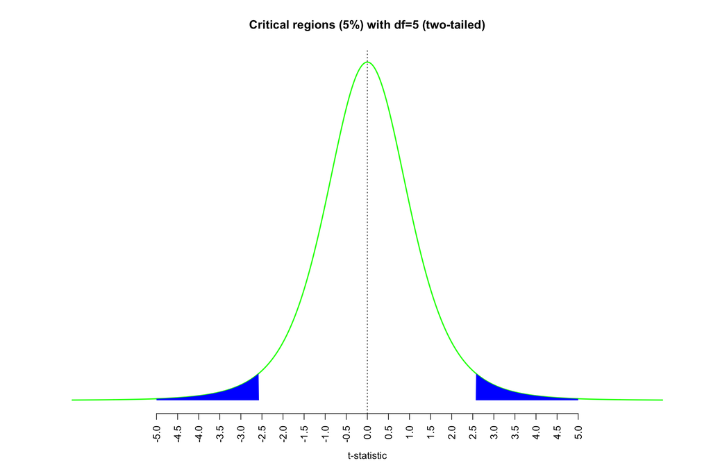

PART 3: one-sample hypothesis testing

## Simple logic

$t = \frac{\overline{X} - \mu}{s_{M}}$

Read as:

$t = \frac{{sample}\ {mean} - H_0\ mean}{estimated\ SE}$

## Scenario

Table 1 from [Measuring Emotions in the COVID-19 Real World Worry Dataset](https://www.aclweb.org/anthology/2020.nlpcovid19-acl.11.pdf)

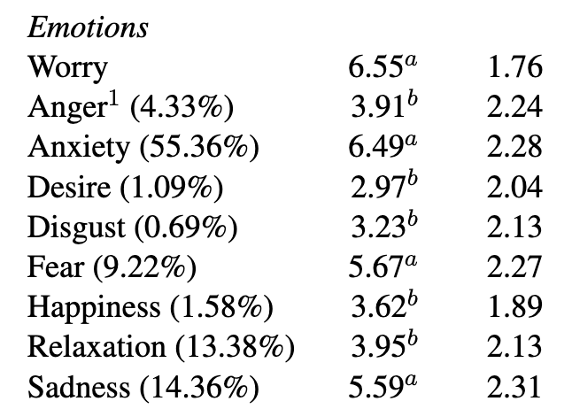

## Are people worried?

Take the worry score:

- Measured on a 9-point scale (1=very low, 5-neutral, 9= very high)
- We know $M=6.55$ and $SD=1.76$
- Suppose $n=41$

The estimated standard error is $s_{M} = \frac{s}{\sqrt{n}} = \frac{1.76}{\sqrt{41}} = 0.27$

We want to test whether people were “worried”.

## Hypotheses

- $H_0: \mu = 5$
- One-tailed case:
  - $H_1: \mu > 5$ (this is **directional**)
  - People are worried (more than neutral)
- Two-tailed case:
  - $H_1: \mu \neq 5$ (this is **non-directional**)
  - People are worried or not worried (different than neutral)

## Critical t-values

Let’s go for $\alpha = .01$

We know: $df = n-1 = 41-1=40$

One-tailed case ($H_1: \mu > 5$): all in one tail.

Two-tailed case ($H_1: \mu \neq 5$): alpha spreads to both tails.

## Table look-up

$\alpha = .01$, $df = 40$

One-tailed case: critical t is $t=2.423$

Two-tailed case: critical t is $t=\pm 2.704$

## Calculating t

$t = \frac{{sample}\ {mean} - H_0\ mean}{estimated\ SE}$

$t = \frac{\overline{X} - \mu}{s_{M}}$

## In the live sessions

- step-wise example

## Recap

- problems with the z-score
- how the t-statistic addresses the “missing population information” problem
- calculating the t-statistic
- hypothesis testing (hyps. alpha, critical region, table look-up, decision)

## Next week

- comparing two groups
- the t-test for two independent samples